# Tutorial: extract m6A and footprints at an LCL promoter (ALAS1)

Crystal Shan

2026-10-09

This example uses the ALAS1 promoter, one of the two LCL promoters (PRDX1, ALAS1) in `code/clustering_methods/Leiden_Manhattan/leiden_LCL.Rmd`, and only functions from `code/parsing_functions/`:

1. build the read x position m6A matrix with `assemble_region_m6a()`
2. plot it as a heatmap without clustering
3. plot the aggregated accessibility profile (m6A fraction of reads per position)
4. plot the nucleosome, TF footprint and FIRE element tracks of the same reads

Reads from all 31 LCL samples are pooled. Only reads spanning the whole window are kept. There is no phasing (the HP tag is never read) and no clustering: reads are ordered by sample, then by read start

# Setup

```r
suppressPackageStartupMessages({
  library(dplyr); library(GenomicRanges); library(Rsamtools); library(Matrix)
})
code_dir <- "/project/spott/cshan/fiber-seq/code/parsing_functions"
source(file.path(code_dir, "parsing_footprints_functions.r"))
source(file.path(code_dir, "plotting_functions.r"))
```

```r
gene     <- "ALAS1"
flank_bp <- 1000L

tss_bed      <- "/project/spott/cshan/annotations/gencodev46_Ensembl_canonical_TSS.bed"
sample_sheet <- "/project/spott/1_Shared_projects/LCL_Fiber_seq/Data/LCL_sample_metatable_merged_samples_31samples.csv"
fire_root    <- "/project/spott/1_Shared_projects/LCL_Fiber_seq/FIRE/results"
tf_root      <- "/project/spott/1_Shared_projects/LCL_Fiber_seq/FiberHMM/FiberHMM_v2/results/results_v1_trained_model"
tabix_bin    <- "/project/spott/cshan/envs/dimelo/bin/tabix"

nuc_size         <- c(130, 160)  # nucleosome size window (bp), the LCL setting of leiden_LCL.Rmd
min_tf_score     <- 50           # FiberHMM v2 per-footprint score floor
pileup_window_bp <- 10           # sliding window of the smoothed m6A fraction

out_dir <- file.path("/project/spott/cshan/fiber-seq/LCL_project/extract_m6a_tutorial", gene)
```

# 1. Region

The canonical TSS BED stores the TSS as a 1 bp interval `[TSS0, TSS0 + 1)` (0-based). As in `leiden_LCL.Rmd`, the window is the 2,000 bp `[TSS0 - 1000, TSS0 + 1000)`: BED `start` / `end`, or 1-based `analysis_start` / `analysis_end`. The 1-based TSS is `TSS0 + 1`.

ALAS1 is on the + strand, so upstream is on the left. To use PRDX1 instead, set `gene <- "PRDX1"`; it is on the - strand, so its upstream side is on the right.

```r
tss <- data.table::fread(tss_bed, header = FALSE, data.table = FALSE,
  col.names = c("chr", "start", "end", "annotation", "score", "strand"))
tss <- tss[vapply(strsplit(tss$annotation, ";", fixed = TRUE), `[`, character(1), 3L) == gene, ]
stopifnot(nrow(tss) == 1L, tss$end - tss$start == 1L)

region <- data.frame(region_id = gene, chr = tss$chr,
  start = tss$start - flank_bp, end = tss$start + flank_bp,                # BED, 0-based start
  analysis_start = tss$start - flank_bp + 1L, analysis_end = tss$start + flank_bp,
  tss = tss$start + 1L, strand = tss$strand)
region
```

```
##   region_id  chr    start      end analysis_start analysis_end      tss strand
## 1     ALAS1 chr3 52197159 52199159       52197160     52199159 52198160      +
```

# 2. Extract the m6A matrix

`assemble_region_m6a()` queries each sample’s `ft extract` m6A BED12 with tabix (`<fire_dir>/extracted_results/m6a_by_chr/<sample>.ft_extracted_m6a.<chr>.bed.gz`), keeps the longest alignment of each read and drops the sentinel blocks.

- `full_span = TRUE` keeps only reads that cover the whole window, so every entry is 1 (m6A call) or 0 (no call).
- `positions` = every base of the window, so the matrix has one column per bp.

Read IDs are `<sample>::<read name>`.

```r
samples <- read.csv(sample_sheet, stringsAsFactors = FALSE)[, c("sample_name", "fire_dir")]

dat <- assemble_region_m6a(samples, region, full_span = TRUE,
  positions = seq(region$analysis_start, region$analysis_end))
dim(dat$met_mat)
```

```
## [1]  534 2000
```

```r
head(dat$rids_df)
```

```
##                                                       RID
## 1 AL6_bc2162_19093::m84241_241120_172940_s3/100664448/ccs
## 2 AL6_bc2162_19093::m84241_241120_172940_s3/164890909/ccs
## 3   AL6_bc2162_19093::m84241_241120_172940_s3/3084813/ccs
## 4 AL6_bc2162_19093::m84241_250514_222554_s2/132252921/ccs
## 5 AL6_bc2162_19093::m84241_250514_222554_s2/166397328/ccs
## 6 AL6_bc2162_19093::m84241_250514_222554_s2/265817825/ccs
##                            original_RID  chr    start      end strand
## 1 m84241_241120_172940_s3/100664448/ccs chr3 52194577 52203172      -
## 2 m84241_241120_172940_s3/164890909/ccs chr3 52196676 52200468      -
## 3   m84241_241120_172940_s3/3084813/ccs chr3 52196152 52201040      -
## 4 m84241_250514_222554_s2/132252921/ccs chr3 52193358 52207176      +
## 5 m84241_250514_222554_s2/166397328/ccs chr3 52195513 52208797      -
## 6 m84241_250514_222554_s2/265817825/ccs chr3 52193478 52200906      +
##        sample_name score
## 1 AL6_bc2162_19093     8
## 2 AL6_bc2162_19093    36
## 3 AL6_bc2162_19093    23
## 4 AL6_bc2162_19093     8
## 5 AL6_bc2162_19093     4
## 6 AL6_bc2162_19093     4
```

```r
dat$qc   # overlapping and full-span reads per sample
```

```
##                              sample_name overlapping_reads full_span_reads
## 1                       AL6_bc2162_19093                10               8
## 2                       AL8_bc2170_19151                13              10
## 3                      AL10_bc2178_19130                21              15
## 4                      AL16_bc2114_18508                15              10
## 5                      AL18_bc2130_18504                12               6
## 6                      AL19_bc2138_18861                13              11
## 7                      AL20_bc2146_19209                38              30
## 8                      AL27_bc2155_18913                 8               7
## 9                      AL28_bc2163_19153                24              17
## 10                     AL30_bc2179_18510                25              19
## 11                     AL38_bc2125_18499                19              15
## 12                     AL39_bc2133_19207                14               9
## 13                     AL43_bc2149_18511                11              11
## 14                     AL44_bc2157_19138                21              15
```

[output cut: 17 more lines]

Read order for all figures: sample sheet order, then read start. No clustering.

```r
rids <- dat$rids_df
rids <- rids[order(match(rids$sample_name, samples$sample_name), rids$start, rids$RID), ]
read_order <- rids$RID
```

The same calls as one row per m6A call, the input of `pileup_reads()` and `plot_region_panels()`:

```r
calls <- Matrix::summary(dat$met_mat)
m6a_calls <- data.frame(RID = rownames(dat$met_mat)[calls$i],
  pos = as.integer(colnames(dat$met_mat))[calls$j], base = "A")
```

# 3. m6A heatmap (no clustering)

Rows are reads in `read_order`, columns are bases; black = m6A call. The dashed line marks the TSS.

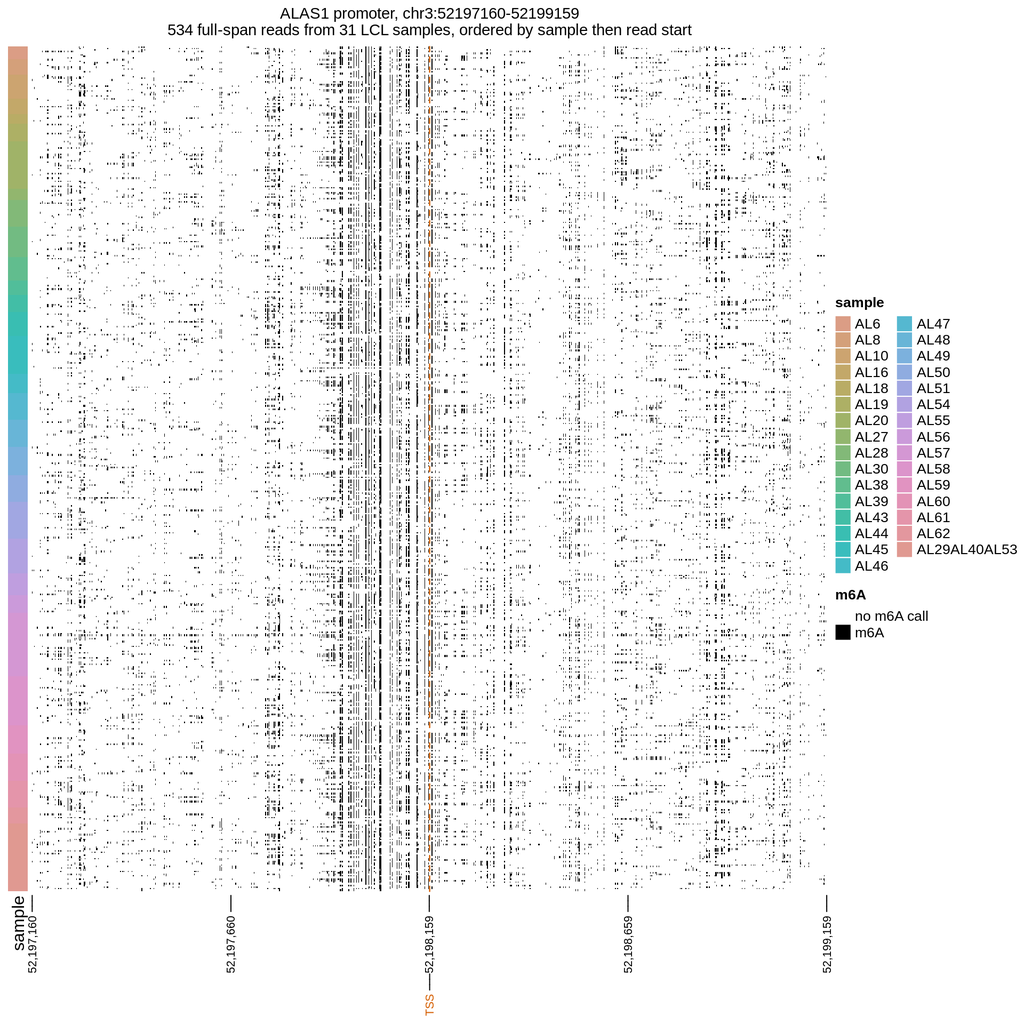

```r
m6a_mat <- as.matrix(dat$met_mat[read_order, , drop = FALSE])
positions <- as.integer(colnames(m6a_mat))
tss_col <- match(region$tss, positions)
ticks <- unique(round(seq(1, ncol(m6a_mat), length.out = 5L)))

sample_label <- factor(sub("_.*$", "", rids$sample_name),
  levels = sub("_.*$", "", samples$sample_name))
sample_colors <- setNames(grDevices::hcl.colors(nlevels(sample_label), "Dynamic"),
  levels(sample_label))

heatmap <- ComplexHeatmap::Heatmap(m6a_mat, name = "m6A",
  col = c("0" = "white", "1" = "black"),
  heatmap_legend_param = list(at = c(0, 1), labels = c("no m6A call", "m6A")),
  cluster_rows = FALSE, cluster_columns = FALSE,
  show_row_names = FALSE, show_column_names = FALSE,
  use_raster = TRUE, raster_quality = 2,
  left_annotation = ComplexHeatmap::rowAnnotation(sample = sample_label,
    col = list(sample = sample_colors),
    annotation_legend_param = list(sample = list(ncol = 2))),
  bottom_annotation = ComplexHeatmap::HeatmapAnnotation(
    coordinate = ComplexHeatmap::anno_mark(at = ticks,
      labels = format(positions[ticks], big.mark = ","), which = "column",
      side = "bottom", labels_gp = grid::gpar(fontsize = 8)),
    TSS = ComplexHeatmap::anno_mark(at = tss_col, labels = "TSS", which = "column",
      side = "bottom", labels_gp = grid::gpar(fontsize = 8, col = "#D55E00")),
    annotation_name_gp = grid::gpar(fontsize = 8)),
  column_title = sprintf("%s promoter, %s:%d-%d\n%d full-span reads from %d LCL samples, ordered by sample then read start",
    gene, region$chr, region$analysis_start, region$analysis_end,
    nrow(m6a_mat), length(unique(rids$sample_name))),
  column_title_gp = grid::gpar(fontsize = 11))

# the TSS line is drawn on the heatmap body after the heatmap itself
draw_heatmap <- function(x) {
  ComplexHeatmap::draw(x, merge_legend = TRUE)
  ComplexHeatmap::decorate_heatmap_body("m6A", {
    grid::grid.lines(x = rep((tss_col - 0.5) / ncol(m6a_mat), 2), y = c(0, 1),
      gp = grid::gpar(col = "#D55E00", lty = "dashed", lwd = 1.2))
  })
}
save_figure(heatmap, file.path(out_dir, "m6a_heatmap.pdf"), width = 10, height = 10,
  draw = draw_heatmap)
draw_heatmap(heatmap)
```

# 4. Aggregated accessibility profile

`pileup_reads()` gives, at every position with at least one m6A call, the fraction of reads with a call there (`frac`), and its `pileup_window_bp` sliding-window mean (`smooth_frac`). All reads span the window, so the denominator is every read.

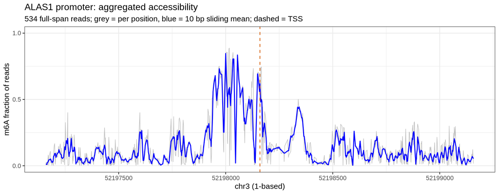

```r
pileup <- pileup_reads(m6a_calls, rids, region$analysis_start, region$analysis_end,
  smooth = TRUE, window_n = pileup_window_bp)

profile_plot <- plot_group_profile(pileup, x_col = "pos", y_col = "smooth_frac",
  layers = list(
    list(geom = "line", mapping = ggplot2::aes(y = frac), colour = "grey75", linewidth = 0.3),
    list(geom = "line", colour = "blue", linewidth = 0.6)),
  markers = list(xintercept = region$tss, linetype = "dashed", colour = "#D55E00"),
  window = c(region$analysis_start, region$analysis_end),
  scales = list(ggplot2::scale_y_continuous(limits = c(0, 1), breaks = c(0, 0.5, 1))),
  labels = list(x = paste(region$chr, "(1-based)"), y = "m6A fraction of reads",
    title = paste(gene, "promoter: aggregated accessibility"),
    subtitle = sprintf("%d full-span reads; grey = per position, blue = %d bp sliding mean; dashed = TSS",
      nrow(rids), pileup_window_bp)),
  theme = theme_fiberseq("bw", base_size = 10))
save_figure(profile_plot, file.path(out_dir, "aggregate_m6a_profile.pdf"), width = 9, height = 3.5)
profile_plot
```

# 5. Footprint tracks

For the same reads, `load_region()` reads the FIRE elements and `load_ft_tracks()` reads:

- nucleosomes: `ft extract` `nuc_by_chr` (kept when `nuc_size[1]` to `nuc_size[2]` bp)
- TF footprints: FiberHMM v2 `<sample>.recalled_tf.bed.gz`, score >= `min_tf_score`, binned into `FP_SIZE_BINS` (half-open 10-30, 40-60, 60-80 bp; other sizes are not drawn)

These functions key reads as `"<sample> <read name>"`.

`load_ft_tracks()` also returns the m6A calls (`$m6a`); this tutorial uses the matrix from step 2 instead.

```r
keys <- paste(rids$sample_name, rids$original_RID)
tracks <- load_region(list(chrom = region$chr, start = region$start, end = region$end),
  samples$sample_name, root = NULL, fire_root = fire_root, tabix_bin = tabix_bin,
  span_source = "fire_all")
tracks <- load_ft_tracks(tracks, keys = keys, ft_root = fire_root, tabix_bin = tabix_bin,
  nuc_source = "ft", tf_source = "recalled_tf", tf_root = tf_root,
  min_tf_score = min_tf_score)

# back to the "<sample>::<read name>" IDs of the m6A matrix
nuc_label <- paste0(nuc_size[1], "-", nuc_size[2], " bp nucleosome")
fire <- as.data.frame(tracks$elements)
fire <- fire[fire$key %in% keys, ]
fire <- data.frame(RID = paste(fire$sample_name, fire$RID, sep = "::"),
  start = fire$start, end = fire$end, class = "FIRE")
nucs <- as.data.frame(tracks$nuc)
nucs <- nucs[!is.na(assign_size_class(nucs$end - nucs$start, nuc_size)), ]
nucs <- data.frame(RID = paste(nucs$sample_name, nucs$RID, sep = "::"),
  start = nucs$start, end = nucs$end, class = nuc_label)
tfs <- as.data.frame(tracks$size_fps)
tfs <- data.frame(RID = paste(tfs$sample_name, tfs$RID, sep = "::"),
  start = tfs$start, end = tfs$end, class = factor(tfs$class, levels = FP_SIZE_BINS))

c(FIRE_elements = nrow(fire), nucleosomes = nrow(nucs), TF_footprints = nrow(tfs))
```

```
## FIRE_elements   nucleosomes TF_footprints
##           647          2723          1014
```

```r
table(tfs$class)
```

```
##
## size10-30 size40-60 size60-80
##       811       156        47
```

`plot_region_panels()` stacks the aggregated profile, the m6A reads and the footprint reads. It draws whatever is in `res$fps_infire`. Here that is every TF footprint, not only the ones inside a FIRE element. ggplot puts the first read level at the bottom, so the levels are reversed to keep the heatmap’s top-to-bottom order.

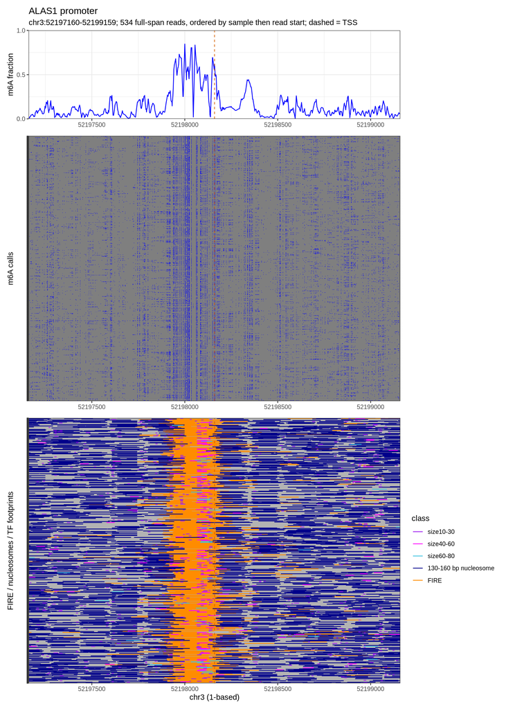

```r
rid_levels <- rev(read_order)
as_read_factor <- function(d) { d$RID <- factor(d$RID, levels = rid_levels); d }
res <- list(
  region     = list(chr = region$chr, start = region$analysis_start, end = region$analysis_end),
  reads      = as_read_factor(m6a_calls),
  rids_df    = as_read_factor(data.frame(RID = rids$RID, start = rids$start, end = rids$end)),
  fire       = as_read_factor(fire),
  nucs       = as_read_factor(nucs),
  fps_infire = as_read_factor(tfs),
  pileup     = pileup,
  size_levels = FP_SIZE_BINS,
  nuc_label  = nuc_label,
  group_col  = NULL)

panels <- plot_region_panels(res,
  plot_name = paste(gene, "promoter"),
  subtitle = sprintf("%s:%d-%d; %d full-span reads, ordered by sample then read start; dashed = TSS",
    region$chr, region$analysis_start, region$analysis_end, nrow(rids)),
  heights = c(pileup = 2, reads = 6, fire_fiberHMM = 6),
  read_options = list(arrows = FALSE),
  y_labels = c(pileup = "m6A fraction", reads = "m6A calls",
               fire_fiberHMM = "FIRE / nucleosomes / TF footprints"),
  x_label = paste(region$chr, "(1-based)"))
footprint_plot <- panels$combined &
  ggplot2::geom_vline(xintercept = region$tss, linetype = "dashed", colour = "#D55E00", linewidth = 0.4)
save_figure(footprint_plot, file.path(out_dir, "footprint_tracks.pdf"), width = 10, height = 14)
footprint_plot
```